# assignment2

## ENV Variables

```python
%config Completer.use_jedi = False
```

```python
%matplotlib inline
```

## Import Libraries

```python
import pandas as pd
import numpy as np
import regex as re
import seaborn as sns
from sklearn.feature_extraction.text import CountVectorizer
from sklearn.cluster import KMeans
from word2number import w2n
from matplotlib import pyplot as plt
```

```python
import nltk
from nltk import word_tokenize
from nltk.corpus import stopwords
from nltk.stem import WordNetLemmatizer
```

```python
nltk.download('stopwords')
```

```
True
```

```python
nltk.download('punkt')
```

```
True
```

```python
nltk.download('wordnet')
```

```
True
```

## 1. Data Description

```python
## Read header information
dddf = pd.read_excel('./data_dictionary.xlsx', sheet_name=2)
```

```python
dddf
```

|  | Order Number | Column Name | Column Description (including the unit of measure, acronyms and range of possible values) | Expected Values |
| --- | --- | --- | --- | --- |
| 0 | 1.0 | Job ID | The job opening identification (“Job ID”) numb... | Plain Text |
| 1 | 2.0 | Agency | Name of the New York City agency (“agency” or ... | Plain Text |
| 2 | 3.0 | Posting Type | Identifies whether a job posting is an Interna... | Plain Text |
| 3 | 4.0 | # Of Positions | The total number of vacancies to be filled und... | Plain Text |
| 4 | 5.0 | Business Title | The "business title", or "office title", for t... | Plain Text |
| 5 | 6.0 | Civil Service Title | The civil service title for the job posting li... | Plain Text |
| 6 | 7.0 | Title Code No. | The Title Code Number (“Title Code No.”) that ... | Plain Text |
| 7 | 8.0 | Level | The civil service title assignment level that ... | Plain Text |
| 8 | 9.0 | Job Category | The occupational group in which the posted job... | Plain Text |
| 9 | 10.0 | Full-Time/Part-Time Indicator | This denotes whether the job is a full time or... | Plain Text |
| 10 | 11.0 | Salary Range From | The lowest salary on a job posting for a posit... | Plain Text |
| 11 | 12.0 | Salary Range To | The highest salary on a job posting for a posi... | Plain Text |
| 12 | 13.0 | Salary Frequency | The frequency of proposed salary. Possible sa... | Plain Text |
| 13 | 14.0 | Work Location | The physical address for the agency listing th... | Plain Text |
| 14 | 15.0 | Division/Work Unit | The department/area within the hiring agency f... | Plain Text |
| 15 | 16.0 | Job Description | The description of the job responsibilities fo... | Plain Text |
| 16 | 17.0 | Minimum Qual Requirements | Minimum qualifications (“minimum qual”) requir... | Plain Text |
| 17 | 18.0 | Preferred Skills | Additional, preferred skills desired by the hi... | Plain Text |
| 18 | 19.0 | Additional Information | Additional information provided by the hiring ... | Plain Text |
| 19 | 20.0 | To Apply | Instructions on how to apply for a given job v... | Plain Text |
| 20 | 21.0 | Hours/Shift | Projected working hours, working days and shif... | Plain Text |
| 21 | 22.0 | Work Location 1 | Where applicable, additional work location det... | Plain Text |
| 22 | 23.0 | Recruitment Contact | Where applicable, recruitment contact informat... | Plain Text |
| 23 | 24.0 | Residency Requirement | Residency requirements for a given job vacancy. | Plain Text |
| 24 | 25.0 | Posting Date | The date and time that a job vacancy was poste... | Plain Text |
| 25 | 25.0 | Post Until | The last date that a job vacancy will be poste... | Plain Text |
| 26 | 26.0 | Posting Updated | The last date and time a job vacancy posting w... | Plain Text |
| 27 | 27.0 | Process Date | The date and time that the dataset created dat... | Plain Text |
| 28 | NaN | NaN | NaN | NaN |
| 29 | NaN | NaN | NaN | NaN |

```python
# Read Data
df = pd.read_csv('./data(4).csv')
```

```python
df.head(2).T
```

|  | 0 | 1 |
| --- | --- | --- |
| Job ID | 87990 | 97899 |
| Agency | DEPARTMENT OF BUSINESS SERV. | DEPARTMENT OF BUSINESS SERV. |
| Posting Type | Internal | Internal |
| # Of Positions | 1 | 1 |
| Business Title | Account Manager | EXECUTIVE DIRECTOR, BUSINESS DEVELOPMENT |
| Civil Service Title | CONTRACT REVIEWER (OFFICE OF L | ADMINISTRATIVE BUSINESS PROMOT |
| Title Code No | 40563 | 10009 |
| Level | 1 | M3 |
| Job Category | NaN | NaN |
| Full-Time/Part-Time indicator | NaN | F |
| Salary Range From | 42405.0 | 60740.0 |
| Salary Range To | 65485.0 | 162014.0 |
| Salary Frequency | Annual | Annual |
| Work Location | 110 William St. N Y | 110 William St. N Y |
| Division/Work Unit | Strategy & Analytics | Tech Talent Pipeline |
| Job Description | Division of Economic & Financial Opportunity (... | The New York City Department of Small Business... |
| Minimum Qual Requirements | 1.\tA baccalaureate degree from an accredited ... | 1. A baccalaureate degree from an accredited c... |
| Preferred Skills | â€¢\tExcellent interpersonal and organizationa... | NaN |
| Additional Information | Salary range for this position is: $42,405 - $... | NaN |
| To Apply | NaN | In addition to applying through this website, ... |
| Hours/Shift | NaN | NaN |
| Work Location 1 | NaN | NaN |
| Recruitment Contact | NaN | NaN |
| Residency Requirement | New York City residency is generally required ... | New York City residency is generally required ... |
| Posting Date | 2011-06-24T00:00:00.000 | 2012-01-26T00:00:00.000 |
| Post Until | NaN | NaN |
| Posting Updated | 2011-06-24T00:00:00.000 | 2012-01-26T00:00:00.000 |
| Process Date | 2019-08-20T00:00:00.000 | 2019-08-20T00:00:00.000 |

### Initial datatypes infered by pandas

```python
df.info()
```

```
<class 'pandas.core.frame.DataFrame'>
RangeIndex: 3228 entries, 0 to 3227
Data columns (total 28 columns):
 #   Column                         Non-Null Count  Dtype
---  ------                         --------------  -----
 0   Job ID                         3228 non-null   int64
 1   Agency                         3228 non-null   object
 2   Posting Type                   3228 non-null   object
 3   # Of Positions                 3228 non-null   int64
 4   Business Title                 3228 non-null   object
 5   Civil Service Title            3228 non-null   object
 6   Title Code No                  3228 non-null   object
 7   Level                          3228 non-null   object
 8   Job Category                   3226 non-null   object
 9   Full-Time/Part-Time indicator  2941 non-null   object
```

[output cut: 20 more lines]

### Convert field types

```python
# Datetime Fields
for col in [
    'Posting Date',
    'Post Until',
    'Posting Updated',
    'Process Date'
]:
    df[col] = pd.to_datetime(df[col])
```

```python
df['Title Code No'].unique()
```

```
array(['40563', '10009', '90698', '91830', '12158', '21822', '1002D',
       '22427', '10251', '1002C', '13642', '10209', '13611', '13632',
       '10124', '13651', '10050', '30080', '91650', '13641', '60910',
       '12627', '10271', '10015', '51022', '51191', '56057', '10056',
       '51193', '13621', '52408', '56058', '13652', '90500', '5072',
       '52632', '52416', '21744', '13631', '30087', '1002A', '31105',
       '30726', '1001A', '10016', '12626', '20403', '20415', '20210',
       '92610', '20315', '20215', '31220', '83008', '21315', '1005A',
       '12202', '13620', '8300B', '95600', '2184C', '34190', '91011',
       '6798', '22425', '30086', '10061', '92235', '91314', '91717',
       '34172', '6082A', '91645', '10025', '95277', '91915', '20310',
       '22305', '91110', '34615', '6088', '40526', '10033', '82801',
       '40510', '13616', '20127', '12200', '22508', '20302', '10095',
       '13389', '21310', '13643', '91001', '1022A', '52615', '34202',
       '91237', '53040', '52040', '95275', '82976', '95005', '20410',
       '22426', '30112', '6316', '31656', '21849', '6804', '21210',
       '52366', '34620', '40502', '51011', '90910', '8300A', '91212',
       '31101', '1002F', '20113', '40410', '40910', '20246', '91644',
       '20617', '82991', '91501', '35116', '20202', '21215', '31165',
       '31143', '90739', '8297A', '13615', '81310', '10026', '31305',
       '13622', '21538', '56056', '10047', '95713', '34221', '10079',
       '8299A', '95710', '95714', '10010', '20616', '10035', '52313',
       '22122', '91279', '60888', '51195', '90641', '6503', '6776',
       '80609', '40562', '13379', '95423', '10074', '95622', '90645',
       '20128', '92611', '22507', '70817', '50910', '80287', '54745',
       '52020', '6743', '30119', '95712', '20271', '60215', '11704',
       '90735', '60216', '92010', '10037', '22315', '60217', '31215',
       '1000B', '90210', '31144', '20122', '6591', '50958', '91308',
       '95711', '80112', '10053', '31312', '5100B', '52311', '20126',
       '90510', '0527A', '1005C', '81803', '0608A', '20618', '52370',
       '95725', '80201', '51263', '52110', '12704', '90644', '10234',
       '34171', '21513', '10174', '80293', '60932', '6611', '35007',
       '6766', '95009', '91415', '12749', '10084', '22503', '70810',
       '52406', '10004', '51310', '50960', '10001', '91547', '40561',
       '51611', '51402', '10147', '31311', '34201', '90650', '90411',
       '22092', '6663', '50415', '95644', '95652', '31662', '5277',
       '31640', '10078', '31675', '1002E', '21537', '6765', '91940',
       '95575', '1020B', '90635', '10022', '8298A', '10252', '81815',
       '91639', '10144', '60816', '13403', '92005', '31145', '95611',
       '6711', '10081', '1002G', '13633', '22124', '52287', '60421',
       '10041', '60860', '10029', '31175', '81350', '10089', '21915',
       '95615', '95613', '5230', '10248', '1007C', '30114', '90622',
       '91619', '81303', '95569', '82011', '80202', '6547', '51613',
       '52633', '80305', '90573', '81361', '1000C', '31622', '54746',
       '31629', '21015', '31623', '91217', '1000A', '95554', '31624',
       '55038', '55018', '33995', '54739', '52369', '5245A', '30121',
       '50959', '91210', '6656', '81106', '82975', '31166', '54741',
       '90647', '95566', '90648', '90702', '52316', '30827', '70314',
       '10049', '60440', '6070', '81111', '92501', '10044', '90723',
       '22117'], dtype=object)
```

```python
df['Salary Frequency'].unique()
```

```
array(['Annual', 'Hourly', 'Daily'], dtype=object)
```

```python
df[df['Salary Frequency']=='Annual']['Salary Range From']
```

```
0       42405.00
1       60740.00
2       51907.68
3       51907.68
6       50598.00
          ...
3223    55416.00
3224    72476.00
3225    72476.00
3226    60433.00
3227    60433.00
Name: Salary Range From, Length: 2955, dtype: float64
```

```python
df[df['Salary Frequency']=='Hourly']['Salary Range From']
```

```
4       35.00
5       35.00
15       8.75
16       8.75
41      32.11
        ...
3162    21.02
3186    17.16
3187    17.16
3202    15.55
3203    15.55
Name: Salary Range From, Length: 237, dtype: float64
```

### Final Datatypes

```python
df.info()
```

```
<class 'pandas.core.frame.DataFrame'>
RangeIndex: 3228 entries, 0 to 3227
Data columns (total 28 columns):
 #   Column                         Non-Null Count  Dtype
---  ------                         --------------  -----
 0   Job ID                         3228 non-null   int64
 1   Agency                         3228 non-null   object
 2   Posting Type                   3228 non-null   object
 3   # Of Positions                 3228 non-null   int64
 4   Business Title                 3228 non-null   object
 5   Civil Service Title            3228 non-null   object
 6   Title Code No                  3228 non-null   object
 7   Level                          3228 non-null   object
 8   Job Category                   3226 non-null   object
 9   Full-Time/Part-Time indicator  2941 non-null   object
```

[output cut: 20 more lines]

## 2. Identification of Variables and Variable Selection

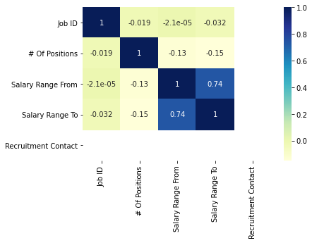

```python
sns.heatmap(df.corr(), annot=True, cmap="YlGnBu")
```

Correlation is a good way to look at data while selecting features but the above correlation does not produce much valuable output as most of the fields are text, we would need to exract the features in the next step and and use them.

So, we will use our hueristics to identify the variables now.

### Q1. What are the highest paid Skills in the US market?

Required Variables:

- Prefrerred Skills
- Salary Range From
- Salary Range To
- Salary Frequency

### Q2. What are the job categories, which involve above mentioned niche skills?

Q1 Required Variables  
along with the following required Variables:

- Job Category

### Q3. Applying clustering concepts, please depict visually what are the different salary ranges based on job category and years of experience

Q1, Q2 Required Variables  
along with the following required Variables:

- Minimum Qual Requirements

## 4. Feature Engineering and cleaning the data

To Do:

- To convert the identified variables to usable format
- Extract features or transform existing features

### Prepare Skills List

The skills are in text format we need to extract skills in form of a list for each row for easy comaprision.

```python
stop_words = set(stopwords.words("english"))
def harmonize_column_text(value):
    a = re.sub('\s+', ' ', re.sub('[^a-zA-z\s]', '', value.lower()))
    a = [x for x in nltk.word_tokenize(a)
                   if not x in stop_words]
    lemma = WordNetLemmatizer()
    a = [lemma.lemmatize(x) for x in a]
    a =" ".join(a)
    return a
```

```python
df['preferred_skills_harmon'] = df.loc[~df['Preferred Skills'].isna(), 'Preferred Skills'].apply(harmonize_column_text)
```

```python
vect = CountVectorizer(ngram_range = (2,2), max_features=100, stop_words="english")
```

```python
skills_tfm = vect.fit_transform(df.loc[~df['preferred_skills_harmon'].isna(), 'preferred_skills_harmon'].values).toarray()
```

```python
skill_df = pd.DataFrame(vect.vocabulary_.items(), columns=['Skill', 'Count'])
```

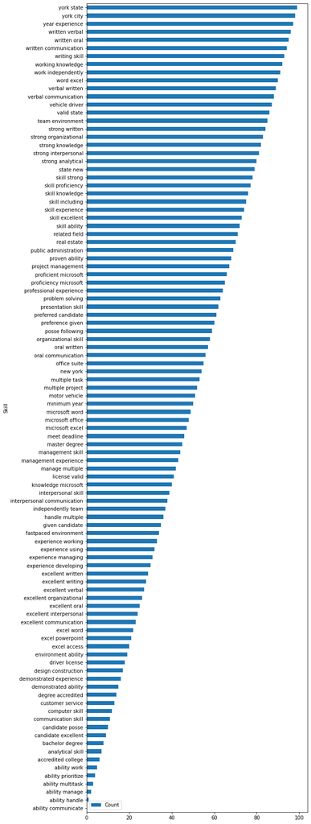

```python
skill_df.sort_values('Count').plot(kind='barh', x='Skill', figsize=(8, 30))
```

### Extract Experience years from text

```python
df['experience_years'] = df['Minimum Qual Requirements'].str.extract('(\d+)\syear.+experience').astype(float)
```

```python
_experience_years = df['Minimum Qual Requirements'].str.extract('(\w+)\syear.+experience')[0]
```

```python
_experience_months = df['Minimum Qual Requirements'].str.extract('(\w+)\smonth.+experience')[0]
```

```python
_experience_years[df['experience_years'].isna()].unique()
```

```
array(['two', 'Three', 'Five', 'half', 'One', 'one', 'four', nan, 'three',
       'Two', 'five', 'a', 'Ten', 'Eight', 'six', 'Four', '8th', 'seven',
       'ten', 'Six', 'Seven', 'more'], dtype=object)
```

```python
exceptions = {
    'half': 0.5,
    'a': 1,
    '8th': 8,
    'more': 0
}
```

```python
def cast(value):
    try:
        return w2n.word_to_num(value)
    except:
        return exceptions[value]
```

```python
df.loc[df['experience_years'].isna(), 'experience_years'] = _experience_years.loc[df['experience_years'].isna() & ~_experience_years.isna()].apply(cast)
```

```python
_experience_months[df['experience_years'].isna()].unique()
```

```
array([nan, '12', 'eighteen', 'Six'], dtype=object)
```

```python
df.loc[df['experience_years'].isna(), 'experience_years'] = _experience_months.loc[df['experience_years'].isna() & ~_experience_months.isna()].apply(cast)/12
```

```python
df['experience_years'].isna().sum()
```

```
457
```

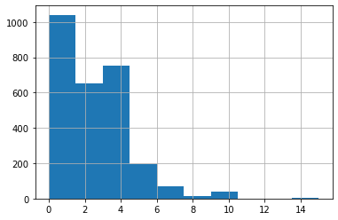

```python
df.experience_years.hist()
```

### Make a common Salary Scale

```python
df['Salary Frequency'].unique()
```

```
array(['Annual', 'Hourly', 'Daily'], dtype=object)
```

To compare the hourly, Daily and annual salary frequency we need to bring them to same scale.

```python
df.info()
```

```
<class 'pandas.core.frame.DataFrame'>
RangeIndex: 3228 entries, 0 to 3227
Data columns (total 30 columns):
 #   Column                         Non-Null Count  Dtype
---  ------                         --------------  -----
 0   Job ID                         3228 non-null   int64
 1   Agency                         3228 non-null   object
 2   Posting Type                   3228 non-null   object
 3   # Of Positions                 3228 non-null   int64
 4   Business Title                 3228 non-null   object
 5   Civil Service Title            3228 non-null   object
 6   Title Code No                  3228 non-null   object
 7   Level                          3228 non-null   object
 8   Job Category                   3226 non-null   object
 9   Full-Time/Part-Time indicator  2941 non-null   object
```

[output cut: 22 more lines]

#### Hourly salary frequency

```python
(df['Salary Frequency'] == 'Hourly').sum()
```

```
237
```

```python
df[df['Salary Frequency'] == 'Hourly']['Hours/Shift']
```

```
4                                                     NaN
5                                                     NaN
15      Hours:  17 hours per week when school is in se...
16      Hours:  17 hours per week when school is in se...
41                                                    NaN
                              ...
3162                                                  NaN
3186                                                  NaN
3187                                                  NaN
3202                       Monday â€“ Friday, 9am to 5pm.
3203                       Monday â€“ Friday, 9am to 5pm.
Name: Hours/Shift, Length: 237, dtype: object
```

```python
df[df['Salary Frequency'] == 'Hourly']['Hours/Shift'].isna().sum()
```

```
204
```

We need to drop the columns with hourly salary frequency because the data required to convert it to annual frequency is not available properly for most of the rows.

```python
df = df[~(df['Salary Frequency'] == 'Hourly')].reset_index()
```

#### Daily salary frequency

```python
df[df['Salary Frequency'] == 'Daily']
```

|  | index | Job ID | Agency | Posting Type | # Of Positions | Business Title | Civil Service Title | Title Code No | Level | Job Category | ... | Hours/Shift | Work Location 1 | Recruitment Contact | Residency Requirement | Posting Date | Post Until | Posting Updated | Process Date | preferred_skills_harmon | experience_years |
| --- | --- | --- | --- | --- | --- | --- | --- | --- | --- | --- | --- | --- | --- | --- | --- | --- | --- | --- | --- | --- | --- |
| 234 | 247 | 284447 | DEPARTMENT OF TRANSPORTATION | Internal | 2 | Electrician | ELECTRICIAN | 91717 | 0 | Building Operations & Maintenance | ... | NaN | 88-20 Pitkin Ave., Ozone Park ***I... | NaN | New York City residency is generally required ... | 2017-03-14 | NaT | 2017-03-14 | 2019-08-20 | knowledge nfpa e electrical safety practice pr... | 5.0 |
| 235 | 248 | 284447 | DEPARTMENT OF TRANSPORTATION | Internal | 2 | Electrician | ELECTRICIAN | 91717 | 0 | Building Operations & Maintenance | ... | NaN | 88-20 Pitkin Ave., Ozone Park ***I... | NaN | New York City residency is generally required ... | 2017-03-14 | NaT | 2017-03-14 | 2019-08-20 | knowledge nfpa e electrical safety practice pr... | 5.0 |
| 276 | 289 | 289636 | DEPARTMENT OF TRANSPORTATION | Internal | 1 | Plumber | PLUMBER | 91915 | 0 | Building Operations & Maintenance | ... | NaN | 88-26 Pitkin Avenue | NaN | New York City residency is generally required ... | 2017-05-17 | NaT | 2017-05-17 | 2019-08-20 | broad based knowledge experience working multi... | 5.0 |
| 326 | 341 | 301758 | DEPARTMENT OF TRANSPORTATION | External | 2 | Electrician | ELECTRICIAN | 91717 | 0 | Building Operations & Maintenance | ... | 35 Hours / Shift To Be Determined | 58-50 57th Road Maspeth, N.Y. / Various | NaN | New York City residency is generally required ... | 2017-08-31 | NaT | 2017-12-20 | 2019-08-20 | knowledge test fiber splicing equipment includ... | 5.0 |
| 327 | 342 | 301758 | DEPARTMENT OF TRANSPORTATION | Internal | 2 | Electrician | ELECTRICIAN | 91717 | 0 | Building Operations & Maintenance | ... | 35 Hours / Shift To Be Determined | 58-50 57th Road Maspeth, N.Y. / Various | NaN | New York City residency is generally required ... | 2017-08-31 | NaT | 2017-12-20 | 2019-08-20 | knowledge test fiber splicing equipment includ... | 5.0 |
| 359 | 380 | 311799 | DEPARTMENT OF TRANSPORTATION | Internal | 1 | Electrician | ELECTRICIAN | 91717 | 0 | Building Operations & Maintenance | ... | NaN | 55 Water St Ny Ny | NaN | New York City residency is generally required ... | 2017-11-01 | NaT | 2017-11-02 | 2019-08-20 | NaN | 5.0 |
| 439 | 464 | 340450 | DEPT OF ENVIRONMENT PROTECTION | External | 1 | Stationary Engineer (Electric) | STATIONARY ENGINEER (ELECTRIC) | 91645 | 0 | Engineering, Architecture, & Planning | ... | NaN | CITYWIDE | NaN | New York City residency is generally required ... | 2018-04-03 | NaT | 2019-01-16 | 2019-08-20 | NaN | 10.0 |
| 440 | 465 | 340450 | DEPT OF ENVIRONMENT PROTECTION | Internal | 1 | Stationary Engineer (Electric) | STATIONARY ENGINEER (ELECTRIC) | 91645 | 0 | Engineering, Architecture, & Planning | ... | NaN | CITYWIDE | NaN | New York City residency is generally required ... | 2018-04-03 | NaT | 2019-01-16 | 2019-08-20 | NaN | 10.0 |
| 632 | 668 | 361694 | DEPT OF ENVIRONMENT PROTECTION | External | 1 | Stationary Engineer (Electric) | STATIONARY ENGINEER (ELECTRIC) | 91645 | 0 | Building Operations & Maintenance | ... | 40 hours per week / May be required to work sh... | 7870 State Road 42 Grahamsville, NY 12740 | NaN | New York City residency is not required for th... | 2018-08-29 | 2019-09-01 | 2019-06-21 | 2019-08-20 | experience knowledge andor certification assoc... | 10.0 |
| 633 | 669 | 361694 | DEPT OF ENVIRONMENT PROTECTION | Internal | 1 | Stationary Engineer (Electric) | STATIONARY ENGINEER (ELECTRIC) | 91645 | 0 | Building Operations & Maintenance | ... | 40 hours per week / May be required to work sh... | 7870 State Road 42 Grahamsville, NY 12740 | NaN | New York City residency is not required for th... | 2018-08-29 | 2019-09-01 | 2019-06-21 | 2019-08-20 | experience knowledge andor certification assoc... | 10.0 |
| 667 | 703 | 365912 | DEPT OF ENVIRONMENT PROTECTION | Internal | 80 | Sewage Treatment Worker | SEWAGE TREATMENT WORKER | 90739 | 0 | Building Operations & Maintenance | ... | 40 hours per week / rotating shifts | Citywide | NaN | New York City residency is generally required ... | 2018-10-01 | NaT | 2018-10-01 | 2019-08-20 | experience industrial construction activity re... | 3.0 |
| 668 | 704 | 365912 | DEPT OF ENVIRONMENT PROTECTION | External | 80 | Sewage Treatment Worker | SEWAGE TREATMENT WORKER | 90739 | 0 | Building Operations & Maintenance | ... | 40 hours per week / rotating shifts | Citywide | NaN | New York City residency is generally required ... | 2018-10-01 | NaT | 2018-10-01 | 2019-08-20 | experience industrial construction activity re... | 3.0 |
| 780 | 818 | 373927 | DEPT OF ENVIRONMENT PROTECTION | External | 15 | Stationary Engineer (Electric) | STATIONARY ENGINEER (ELECTRIC) | 91645 | 0 | Building Operations & Maintenance | ... | 40 hours per week / day | Various – Citywide | NaN | New York City residency is generally required ... | 2018-11-09 | NaT | 2018-11-09 | 2019-08-20 | NaN | 10.0 |
| 781 | 819 | 373927 | DEPT OF ENVIRONMENT PROTECTION | Internal | 15 | Stationary Engineer (Electric) | STATIONARY ENGINEER (ELECTRIC) | 91645 | 0 | Building Operations & Maintenance | ... | 40 hours per week / day | Various – Citywide | NaN | New York City residency is generally required ... | 2018-11-09 | NaT | 2018-11-09 | 2019-08-20 | NaN | 10.0 |
| 782 | 820 | 373928 | DEPT OF ENVIRONMENT PROTECTION | Internal | 15 | Stationary Engineer (Electric) | STATIONARY ENGINEER (ELECTRIC) | 91645 | 0 | Building Operations & Maintenance | ... | 40 hours per week / day | Various – Citywide | NaN | New York City residency is generally required ... | 2018-11-09 | NaT | 2018-11-09 | 2019-08-20 | NaN | 10.0 |
| 1085 | 1144 | 383624 | DEPARTMENT OF TRANSPORTATION | Internal | 1 | Roofer | ROOFER | 90735 | 0 | Building Operations & Maintenance | ... | NaN | 88-26 Pitkin Avenue | NaN | New York City residency is generally required ... | 2019-07-29 | 2019-09-24 | 2019-07-29 | 2019-08-20 | NaN | 15.0 |
| 1091 | 1152 | 383826 | DEPARTMENT OF TRANSPORTATION | External | 8 | Dockbuilder | DOCKBUILDER | 92010 | 0 | Building Operations & Maintenance | ... | 40 Hours / Monday-Friday; plus overtime | 1 Bay Street, Staten Island, NY 10301 | NaN | New York City residency is generally required ... | 2019-02-14 | NaT | 2019-02-14 | 2019-08-20 | NaN | 5.0 |
| 1092 | 1153 | 383826 | DEPARTMENT OF TRANSPORTATION | Internal | 8 | Dockbuilder | DOCKBUILDER | 92010 | 0 | Building Operations & Maintenance | ... | 40 Hours / Monday-Friday; plus overtime | 1 Bay Street, Staten Island, NY 10301 | NaN | New York City residency is generally required ... | 2019-02-14 | NaT | 2019-02-14 | 2019-08-20 | NaN | 5.0 |
| 1718 | 1845 | 395440 | DEPARTMENT OF SANITATION | External | 1 | STATIONARY ENGINEER | STATIONARY ENGINEER | 91644 | 0 | Engineering, Architecture, & Planning | ... | To Be Determined | 58-73 53 Avenue, Queens Ny | NaN | New York City Residency is not required for th... | 2019-08-13 | NaT | 2019-08-13 | 2019-08-20 | motor vehicle driver license valid state new y... | NaN |
| 1719 | 1846 | 395440 | DEPARTMENT OF SANITATION | Internal | 1 | STATIONARY ENGINEER | STATIONARY ENGINEER | 91644 | 0 | Engineering, Architecture, & Planning | ... | To Be Determined | 58-73 53 Avenue, Queens Ny | NaN | New York City Residency is not required for th... | 2019-08-13 | NaT | 2019-08-13 | 2019-08-20 | motor vehicle driver license valid state new y... | NaN |
| 2012 | 2181 | 398191 | DEPT OF HEALTH/MENTAL HYGIENE | External | 1 | City Medical Specialist, Bureau of Tuberculos... | CITY MEDICAL SPECIALIST (PART- | 53040 | 4 | Health | ... | NaN | NaN | NaN | New York City Residency is not required for th... | 2019-07-09 | 2019-10-07 | 2019-07-09 | 2019-08-20 | supervisory experience knowledge public health... | 1.0 |
| 2013 | 2182 | 398191 | DEPT OF HEALTH/MENTAL HYGIENE | Internal | 1 | City Medical Specialist, Bureau of Tuberculos... | CITY MEDICAL SPECIALIST (PART- | 53040 | 4 | Health | ... | NaN | NaN | NaN | New York City Residency is not required for th... | 2019-07-09 | 2019-10-07 | 2019-07-09 | 2019-08-20 | supervisory experience knowledge public health... | 1.0 |
| 2081 | 2258 | 398772 | DEPARTMENT OF TRANSPORTATION | External | 8 | Electrician | ELECTRICIAN | 91717 | 0 | Building Operations & Maintenance | ... | 35 Hours / Shift TBD | TBD | NaN | New York City residency is generally required ... | 2019-06-27 | NaT | 2019-07-19 | 2019-08-20 | knowledge test fiber splicing equipment includ... | 5.0 |
| 2082 | 2259 | 398772 | DEPARTMENT OF TRANSPORTATION | Internal | 8 | Electrician | ELECTRICIAN | 91717 | 0 | Building Operations & Maintenance | ... | 35 Hours / Shift TBD | TBD | NaN | New York City residency is generally required ... | 2019-06-27 | NaT | 2019-07-19 | 2019-08-20 | knowledge test fiber splicing equipment includ... | 5.0 |
| 2193 | 2374 | 399442 | DEPT OF CITYWIDE ADMIN SVCS | External | 1 | Maintenance Worker | MAINTENANCE WORKER | 90698 | 0 | Building Operations & Maintenance | ... | NaN | 130 Stuyvesant Place, Staten Island, New York | NaN | New York City residency is generally required ... | 2019-07-31 | 2019-08-30 | 2019-07-31 | 2019-08-20 | applicant basic knowledge boiler chiller cooli... | 3.0 |
| 2194 | 2375 | 399442 | DEPT OF CITYWIDE ADMIN SVCS | Internal | 1 | Maintenance Worker | MAINTENANCE WORKER | 90698 | 0 | Building Operations & Maintenance | ... | NaN | 130 Stuyvesant Place, Staten Island, New York | NaN | New York City residency is generally required ... | 2019-07-31 | 2019-08-30 | 2019-07-31 | 2019-08-20 | applicant basic knowledge boiler chiller cooli... | 3.0 |
| 2592 | 2805 | 403438 | DEPT OF ENVIRONMENT PROTECTION | External | 1 | Stationary Engineer (Electric) | STATIONARY ENGINEER (ELECTRIC) | 91645 | 0 | Building Operations & Maintenance | ... | 40 Hours per week / Shift work may be required... | 3701 Jerome Avenue Bronx, NY 10467 | NaN | New York City residency is generally required ... | 2019-07-31 | 2019-08-30 | 2019-07-31 | 2019-08-20 | motor vehicle driver license valid state new y... | 10.0 |
| 2593 | 2806 | 403438 | DEPT OF ENVIRONMENT PROTECTION | Internal | 1 | Stationary Engineer (Electric) | STATIONARY ENGINEER (ELECTRIC) | 91645 | 0 | Building Operations & Maintenance | ... | 40 Hours per week / Shift work may be required... | 3701 Jerome Avenue Bronx, NY 10467 | NaN | New York City residency is generally required ... | 2019-07-31 | 2019-08-30 | 2019-07-31 | 2019-08-20 | motor vehicle driver license valid state new y... | 10.0 |
| 2604 | 2817 | 403485 | DEPT OF CITYWIDE ADMIN SVCS | Internal | 2 | Maintenance Worker | MAINTENANCE WORKER | 90698 | 0 | Building Operations & Maintenance | ... | NaN | NaN | NaN | New York City residency is generally required ... | 2019-07-31 | NaT | 2019-08-01 | 2019-08-20 | NaN | 3.0 |
| 2605 | 2818 | 403485 | DEPT OF CITYWIDE ADMIN SVCS | External | 2 | Maintenance Worker | MAINTENANCE WORKER | 90698 | 0 | Building Operations & Maintenance | ... | NaN | NaN | NaN | New York City residency is generally required ... | 2019-07-31 | NaT | 2019-08-01 | 2019-08-20 | NaN | 3.0 |
| 2867 | 3095 | 405792 | DEPARTMENT OF TRANSPORTATION | External | 4 | High Pressure Plant Tender | HIGH PRESSURE PLANT TENDER | 91650 | 0 | Building Operations & Maintenance | ... | 40 hours/variable, including nights/weekends | St. George and Whitehall Ferry Terminals | NaN | New York City residency is generally required ... | 2019-08-14 | 2019-09-13 | 2019-08-14 | 2019-08-20 | basic knowledge computer preferably knowledge ... | 2.0 |
| 2868 | 3096 | 405792 | DEPARTMENT OF TRANSPORTATION | Internal | 4 | High Pressure Plant Tender | HIGH PRESSURE PLANT TENDER | 91650 | 0 | Building Operations & Maintenance | ... | 40 hours/variable, including nights/weekends | St. George and Whitehall Ferry Terminals | NaN | New York City residency is generally required ... | 2019-08-14 | 2019-09-13 | 2019-08-14 | 2019-08-20 | basic knowledge computer preferably knowledge ... | 2.0 |
| 2890 | 3118 | 405910 | DEPARTMENT OF TRANSPORTATION | External | 1 | City Laborer | CITY LABORER | 90702 | 0 | Building Operations & Maintenance | ... | NaN | 55 Water St Ny Ny | NaN | New York City residency is generally required ... | 2019-08-14 | 2020-02-10 | 2019-08-14 | 2019-08-20 | ideal candidate motivated individual able work... | NaN |
| 2891 | 3119 | 405910 | DEPARTMENT OF TRANSPORTATION | Internal | 1 | City Laborer | CITY LABORER | 90702 | 0 | Building Operations & Maintenance | ... | NaN | 55 Water St Ny Ny | NaN | New York City residency is generally required ... | 2019-08-14 | 2020-02-10 | 2019-08-14 | 2019-08-20 | ideal candidate motivated individual able work... | NaN |
| 2961 | 3196 | 406487 | DEPARTMENT OF CORRECTION | External | 2 | LOCKSMITH | LOCKSMITH | 90723 | 0 | Building Operations & Maintenance | ... | NaN | NaN | NaN | New York City residency is generally required ... | 2019-08-19 | 2019-09-02 | 2019-08-19 | 2019-08-20 | NaN | 5.0 |
| 2962 | 3197 | 406487 | DEPARTMENT OF CORRECTION | Internal | 2 | LOCKSMITH | LOCKSMITH | 90723 | 0 | Building Operations & Maintenance | ... | NaN | NaN | NaN | New York City residency is generally required ... | 2019-08-19 | 2019-09-02 | 2019-08-19 | 2019-08-20 | NaN | 5.0 |

36 rows × 31 columns

```python
df[df['Salary Frequency'] == 'Daily']['Hours/Shift']
```

```
234                                                   NaN
235                                                   NaN
276                                                   NaN
326                     35 Hours / Shift To Be Determined
327                     35 Hours / Shift To Be Determined
359                                                   NaN
439                                                   NaN
440                                                   NaN
632     40 hours per week / May be required to work sh...
633     40 hours per week / May be required to work sh...
667                   40 hours per week / rotating shifts
668                   40 hours per week / rotating shifts
780                               40 hours per week / day
781                               40 hours per week / day
782                               40 hours per week / day
```

[output cut: 22 more lines]

```python
(df['Salary Frequency'] == 'Daily').sum()
```

```
36
```

```python
df[df['Salary Frequency'] == 'Daily']['Hours/Shift'].isna().sum()
```

```
17
```

```python
df = df[~(df['Salary Frequency'] == 'Daily')].reset_index()
```

### Plotting correlation again

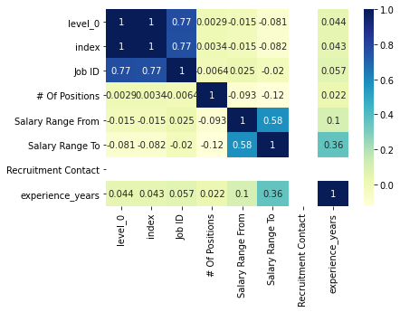

```python
sns.heatmap(df.corr(), annot=True, cmap="YlGnBu")
```

We can see that there is a slight correlation between the

- 'Salary Range To' and 'experience years'

## 5. Missing value or data

### Find columns with no data

```python
def plot_na(df):
    store = []
    for col in df.columns:
        nodata_r = df[col].isna().sum()*100/len(df)
        if nodata_r > 0:
            store.append({
                "Column": col,
                "% Nodata":  nodata_r
            })
            print(f"-- Column: {col} | % Nodata: {(nodata_r):0.2f} %")
    if len(store) > 0:
        pd.DataFrame(store)\
        .sort_values('% Nodata', False)\
        .plot(kind='bar',x='Column', y='% Nodata')
    else:
        print("-- supplied dataframe has no NoData values")
```

```
-- Column: Job Category | % Nodata: 0.07 %
-- Column: Full-Time/Part-Time indicator | % Nodata: 9.31 %
-- Column: Minimum Qual Requirements | % Nodata: 0.47 %
-- Column: Preferred Skills | % Nodata: 11.51 %
-- Column: Additional Information | % Nodata: 40.24 %
-- Column: To Apply | % Nodata: 0.03 %
-- Column: Hours/Shift | % Nodata: 66.06 %
-- Column: Work Location 1 | % Nodata: 53.10 %
-- Column: Recruitment Contact | % Nodata: 100.00 %
-- Column: Post Until | % Nodata: 70.49 %
-- Column: preferred_skills_harmon | % Nodata: 11.51 %
-- Column: experience_years | % Nodata: 11.54 %
```

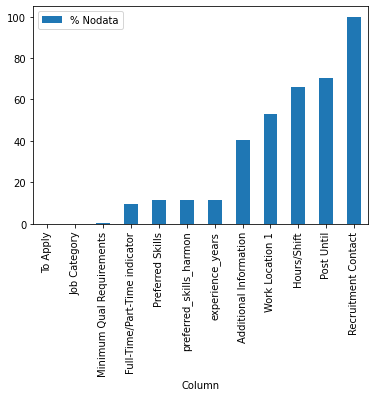

```python
plot_na(df)
```

### Drop columns with no information

```python
# Recruitment Contact is totally null we can safely drop it
df.drop('Recruitment Contact', 1, inplace=True)
```

## Drop not required columns

```python
fdf = df[['preferred_skills_harmon', 'Job Category', 'Salary Range From', 'Salary Range To', 'experience_years']].reset_index(drop=True)
```

```python
fdf = fdf[~fdf.isna().any(1)]
```

```python
plot_na(fdf)
```

```
-- supplied dataframe has no NoData values
```

## 6. Analysis

```python
fdf.head()
```

|  | preferred_skills_harmon | Job Category | Salary Range From | Salary Range To | experience_years |
| --- | --- | --- | --- | --- | --- |
| 2 | high school diploma ged cdl driver license exc... | Maintenance & Operations | 51907.68 | 54580.32 | 3.0 |
| 3 | high school diploma ged cdl driver license exc... | Maintenance & Operations | 51907.68 | 54580.32 | 3.0 |
| 4 | strong analytical background advanced proficie... | Finance, Accounting, & Procurement | 50598.00 | 85053.00 | 0.5 |
| 5 | order apply position candidate must permanent ... | Health Public Safety, Inspections, & Enforcement | 50623.00 | 75083.00 | 2.0 |
| 6 | five year managerial supervisory experience ex... | Engineering, Architecture, & Planning | 90000.00 | 110000.00 | 2.0 |

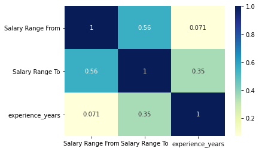

```python
sns.heatmap(fdf.corr(), annot=True, cmap="YlGnBu")
```

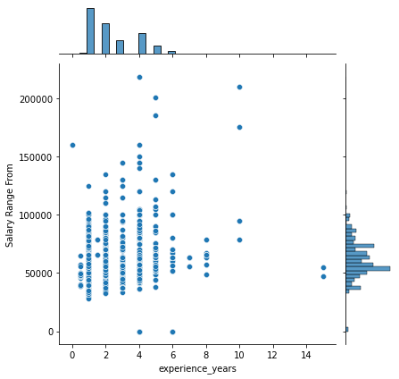

```python
sns.jointplot(x='experience_years', y='Salary Range From', data=fdf)
```

### Grouping 'Job Category' after cleaning a bit

```python
def get_job_cats(value):
    store = []
    for x in value.split(','):
        store.extend(x.split('&'))
#         store.append(x.strip())
    store = [x.strip() for x in store]
    store = [x for x in store if x!='']
    return store
```

```python
fdf['Job Cats'] = fdf['Job Category'].apply(get_job_cats)
```

```python
store = []
for _, row in fdf.iterrows():
    for x in row['Job Cats']:
        store.append({
            'Job Cat': x,
            'Salary Range From': row['Salary Range From'],
            'Salary Range To': row['Salary Range To']
        })
#
jdf = pd.DataFrame(store)
jdf.head()
```

|  | Job Cat | Salary Range From | Salary Range To |
| --- | --- | --- | --- |
| 0 | Maintenance | 51907.68 | 54580.32 |
| 1 | Operations | 51907.68 | 54580.32 |
| 2 | Maintenance | 51907.68 | 54580.32 |
| 3 | Operations | 51907.68 | 54580.32 |
| 4 | Finance | 50598.00 | 85053.00 |

```python
_jdf = pd.concat([
    jdf.groupby('Job Cat').min('Salary Range From')['Salary Range From'],
    jdf.groupby('Job Cat').min('Salary Range From')['Salary Range To'],
    jdf[['Job Cat']].reset_index().groupby('Job Cat').count()
], 1)#.sort_values('Salary Range To', ascending=False)
_jdf.columns = (_jdf.columns[:-1].tolist()+['count'])
len(_jdf)
```

```
100
```

```python
_jdf.head()
```

| Job Cat | Salary Range From | Salary Range To | count |
| --- | --- | --- | --- |
| Accounting | 37217.0 | 46747.0 | 189 |
| Administration | 31893.0 | 36677.0 | 227 |
| Administrative Support | 28965.0 | 43152.0 | 10 |
| Administrative Support Community | 53373.0 | 72000.0 | 1 |
| Administrative Support Legal | 37492.0 | 53300.0 | 4 |

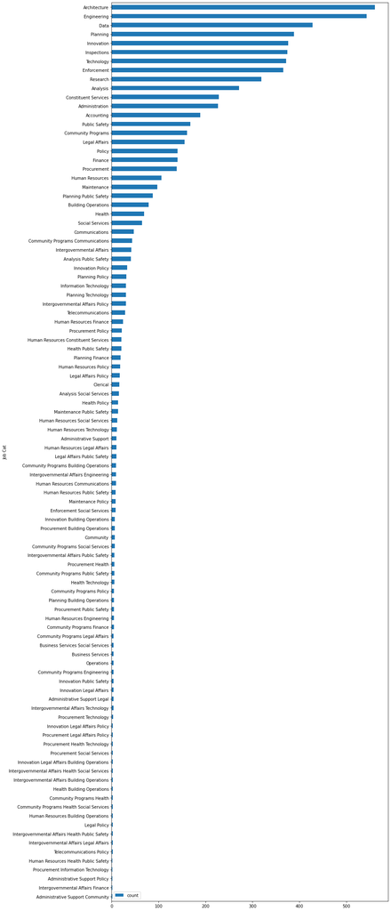

```python
_jdf.sort_values('count')[['count']].plot(kind='barh', figsize=(12, 40))
```

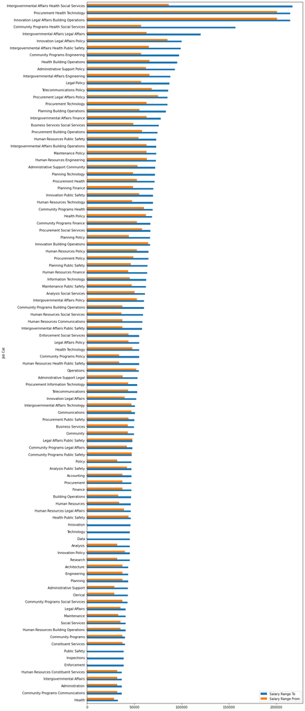

```python
_jdf.sort_values('Salary Range To')[['Salary Range To', 'Salary Range From']].plot(kind='barh', figsize=(12, 40))
```

## Questions

### Q1 What are the highest paid Skills in the US market?

```python
fdf.head()
```

|  | preferred_skills_harmon | Job Category | Salary Range From | Salary Range To | experience_years | Job Cats |
| --- | --- | --- | --- | --- | --- | --- |
| 2 | high school diploma ged cdl driver license exc... | Maintenance & Operations | 51907.68 | 54580.32 | 3.0 | [Maintenance, Operations] |
| 3 | high school diploma ged cdl driver license exc... | Maintenance & Operations | 51907.68 | 54580.32 | 3.0 | [Maintenance, Operations] |
| 4 | strong analytical background advanced proficie... | Finance, Accounting, & Procurement | 50598.00 | 85053.00 | 0.5 | [Finance, Accounting, Procurement] |
| 5 | order apply position candidate must permanent ... | Health Public Safety, Inspections, & Enforcement | 50623.00 | 75083.00 | 2.0 | [Health Public Safety, Inspections, Enforcement] |
| 6 | five year managerial supervisory experience ex... | Engineering, Architecture, & Planning | 90000.00 | 110000.00 | 2.0 | [Engineering, Architecture, Planning] |

```python
_sdf = pd.concat([
    df.groupby('preferred_skills_harmon').min('Salary Range From')['Salary Range From'],
    df.groupby('preferred_skills_harmon').min('Salary Range From')['Salary Range To'],
    df[['preferred_skills_harmon']].reset_index().groupby('preferred_skills_harmon').count()
], 1).reset_index(drop=False)
```

```python
_sdf.head()
```

|  | preferred_skills_harmon | Salary Range From | Salary Range To | index |
| --- | --- | --- | --- | --- |
| 0 | ability apply high level independent judgment ... | 60403.0 | 70000.0 | 2 |
| 1 | ability climb stair ladder engage extensive wa... | 52000.0 | 52000.0 | 2 |
| 2 | ability climb stair ladder engage extensive wa... | 46010.0 | 46010.0 | 2 |
| 3 | ability code net java script scratch year expe... | 55556.0 | 82776.0 | 4 |
| 4 | ability combine quantitative qualitative infor... | 95000.0 | 105000.0 | 2 |

#### Find Median upper edge of Salary Range

Here we are taking the median of 'Salary Range To' for all the jobs matching with the respective skills.

```python
skill_df['maxSalaryMin'] = 0.0
skill_df['maxSalaryMax'] = 0.0
skill_df['maxSalaryMedian'] = 0.0
blocked = ['skill', 'ability work', 'experience working', 'skill experience', 'year experience', 'new york', 'posse following', 'candidate posse', 'preferred candidate', 'york city', 'minimum year']
for i, row in skill_df.iterrows():
    a = False
    for b in blocked:
        if row.Skill[:len(b)] == b:
            a = True
            continue
    if a: continue
    mask = fdf.preferred_skills_harmon.str.contains(row.Skill)
#     skill_df.loc[i, 'minSalary'] = _sdf.loc[mask, 'Salary Range From'].min()
    skill_df.loc[i, 'maxSalaryMin'] = fdf.loc[mask, 'Salary Range To'].min()
    skill_df.loc[i, 'maxSalaryMax'] = fdf.loc[mask, 'Salary Range To'].max()
    skill_df.loc[i, 'maxSalaryMedian'] = fdf.loc[mask, 'Salary Range To'].median()
```

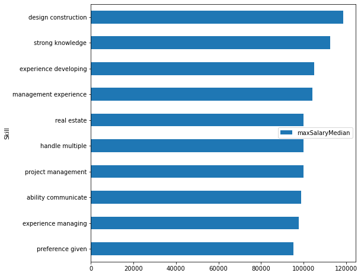

```python
_sdf = skill_df.groupby('Skill') \
.first()[['maxSalaryMedian']] \
.sort_values('maxSalaryMedian').tail(10)
#
_sdf.plot(kind='barh', figsize=(8, 8))
```

#### List showing top paid skills by max Salary Median

```python
_sdf[::-1]
```

| Skill | maxSalaryMedian |
| --- | --- |
| design construction | 118610.0 |
| strong knowledge | 112711.5 |
| experience developing | 105000.0 |
| management experience | 104182.0 |
| real estate | 100000.0 |
| handle multiple | 100000.0 |
| project management | 100000.0 |
| ability communicate | 98908.0 |
| experience managing | 97873.0 |
| preference given | 95270.0 |

#### If you want to take a look at min and max values also for Max Salary paid here is the table

```python
skill_df.groupby('Skill') \
.first() \
.sort_values('maxSalaryMedian').tail(10)[::-1]
```

| Skill | Count | maxSalaryMin | maxSalaryMax | maxSalaryMedian |
| --- | --- | --- | --- | --- |
| design construction | 17 | 75000.0 | 186555.0 | 118610.0 |
| strong knowledge | 82 | 52524.0 | 186555.0 | 112711.5 |
| experience developing | 30 | 66748.0 | 178873.0 | 105000.0 |
| management experience | 43 | 48183.0 | 225217.0 | 104182.0 |
| real estate | 70 | 50000.0 | 224749.0 | 100000.0 |
| handle multiple | 36 | 49586.0 | 178873.0 | 100000.0 |
| project management | 67 | 51902.0 | 225217.0 | 100000.0 |
| ability communicate | 0 | 46669.0 | 224749.0 | 98908.0 |
| experience managing | 31 | 45000.0 | 234402.0 | 97873.0 |
| preference given | 60 | 47000.0 | 168433.0 | 95270.0 |

## Q2 What are the job categories, which involve above mentioned niche skills?

```python
for i, row in skill_df.iterrows():
    a = False
    for b in blocked:
        if row.Skill[:len(b)] == b:
            a = True
            continue
    if a: continue
    mask = fdf.preferred_skills_harmon.str.contains(row.Skill)
#     skill_df.loc[i, 'minSalary'] = _sdf.loc[mask, 'Salary Range From'].min()
    skill_df.loc[i, 'maxSalaryMin'] = fdf.loc[mask, 'Salary Range To'].min()
    skill_df.loc[i, 'maxSalaryMax'] = fdf.loc[mask, 'Salary Range To'].max()
    skill_df.loc[i, 'maxSalaryMedian'] = fdf.loc[mask, 'Salary Range To'].median()
```

```python
store = {}
for skill in _sdf.index:
    for jobcats in fdf[fdf.preferred_skills_harmon.str.contains(skill)]['Job Cats']:
        for j in jobcats:
            if j not in store:
                store[j] = {
                    'Job Category': j,
                    'Count': 1,
                    'Skill': skill,
                    'Skills': [skill]
                }
            if skill != store[j]['Skill']:
                store[j]['Count']+=1
                store[j]['Skill'] = skill
                store[j]['Skills'].append(skill)
#
job_skill_df = pd.DataFrame(store.values())
job_skill_df.head()
```

|  | Job Category | Count | Skill | Skills |
| --- | --- | --- | --- | --- |
| 0 | Public Safety | 8 | strong knowledge | [preference given, experience managing, abilit... |
| 1 | Inspections | 9 | design construction | [preference given, experience managing, abilit... |
| 2 | Enforcement | 9 | design construction | [preference given, experience managing, abilit... |
| 3 | Technology | 9 | strong knowledge | [preference given, experience managing, abilit... |
| 4 | Data | 10 | design construction | [preference given, experience managing, abilit... |

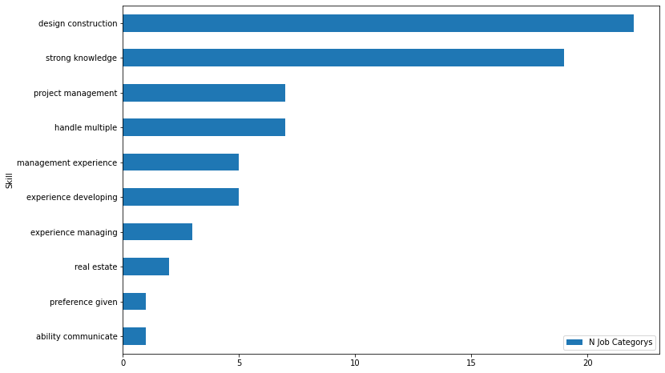

```python
_sjdf = job_skill_df[['Skill']].reset_index().groupby('Skill').count()
_sjdf.columns = ['N Job Categorys']
_sjdf = _sjdf.sort_values('N Job Categorys')
_sjdf.plot(kind='barh', figsize=(12, 8))
```

The following table shows that the highest paid skill is present in how many job categories

```python
_sjdf[::-1]
```

| Skill | N Job Categorys |
| --- | --- |
| design construction | 22 |
| strong knowledge | 19 |
| project management | 7 |
| handle multiple | 7 |
| management experience | 5 |
| experience developing | 5 |
| experience managing | 3 |
| real estate | 2 |
| preference given | 1 |
| ability communicate | 1 |

The following list shows the job categories demanding the top paid skills

```python
_jsdf = job_skill_df[['Count']]
_jsdf.index = job_skill_df['Job Category']
_jsdf.columns = ['N Skills']
_jsdf = _jsdf.sort_values('N Skills', ascending=False)
_jsdf.head(10)
```

| Job Category | N Skills |
| --- | --- |
| Engineering | 10 |
| Architecture | 10 |
| Analysis | 10 |
| Research | 10 |
| Planning | 10 |
| Accounting | 10 |
| Data | 10 |
| Administration | 9 |
| Inspections | 9 |
| Innovation | 9 |

```python
with pd.option_context('display.max_rows', None, 'display.max_columns', None):  # more options can be specified also
    print(_jsdf.reset_index())
```

```
                                        Job Category  N Skills
0                                        Engineering        10
1                                       Architecture        10
2                                           Analysis        10
3                                           Research        10
4                                           Planning        10
5                                         Accounting        10
6                                               Data        10
7                                     Administration         9
8                                        Inspections         9
9                                         Innovation         9
10                              Constituent Services         9
11                            Planning Public Safety         9
12                                        Technology         9
13                                       Enforcement         9
```

[output cut: 58 more lines]

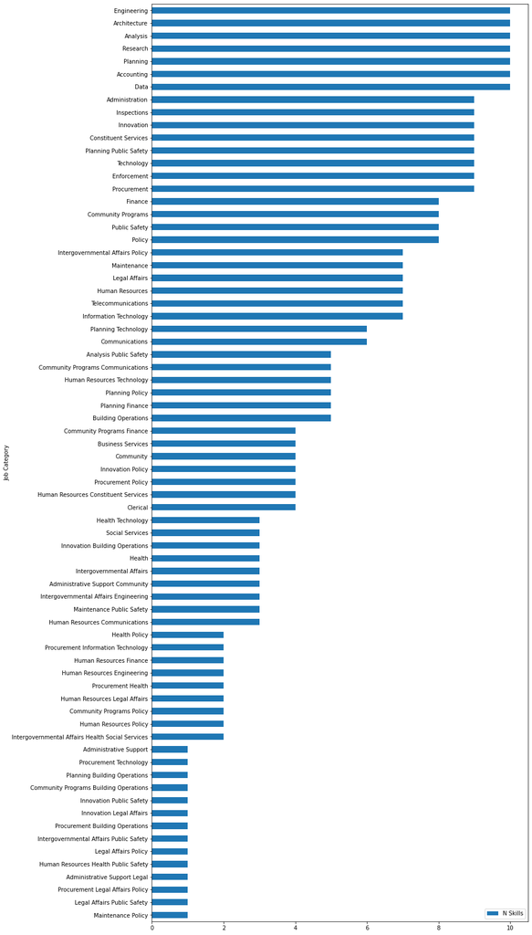

```python
_jsdf[::-1].plot(kind='barh', figsize=(12, 30))
```

## Q3 Applying clustering concepts, please depict visually what are the different salary ranges based on job category and years of experience.

```python
store = []
for _, row in fdf.iterrows():
    for x in row['Job Cats']:
        store.append({
            'Job Cat': x,
            'experience_years': row['experience_years'],
            'Salary Range From': row['Salary Range From'],
            'Salary Range To': row['Salary Range To']
        })
#
jedf = pd.DataFrame(store)
jedf.head()
```

|  | Job Cat | experience_years | Salary Range From | Salary Range To |
| --- | --- | --- | --- | --- |
| 0 | Maintenance | 3.0 | 51907.68 | 54580.32 |
| 1 | Operations | 3.0 | 51907.68 | 54580.32 |
| 2 | Maintenance | 3.0 | 51907.68 | 54580.32 |
| 3 | Operations | 3.0 | 51907.68 | 54580.32 |
| 4 | Finance | 0.5 | 50598.00 | 85053.00 |

```python
col = columns=['JobCat', 'experience_years', 'Salary']
jedf = pd.concat([
    pd.DataFrame(jedf[['Job Cat', 'experience_years', 'Salary Range From']].values, columns=col),
    pd.DataFrame(jedf[['Job Cat', 'experience_years', 'Salary Range To']].values, columns=col),
])
```

```python
_jedf = jedf.copy()
```

```python
jedf['experience_years'] = (jedf['experience_years']-jedf['experience_years'].min())/(jedf['experience_years'].max()-jedf['experience_years'].min())
```

```python
jedf['Salary'] = (jedf['Salary']-jedf['Salary'].min())/(jedf['Salary'].max()-jedf['Salary'].min())
```

```python
jedf.head()
```

|  | JobCat | experience_years | Salary |
| --- | --- | --- | --- |
| 0 | Maintenance | 0.2 | 0.221447 |
| 1 | Operations | 0.2 | 0.221447 |
| 2 | Maintenance | 0.2 | 0.221447 |
| 3 | Operations | 0.2 | 0.221447 |
| 4 | Finance | 0.033333 | 0.21586 |

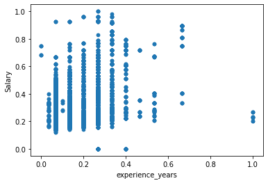

```python
jedf.plot.scatter(x='experience_years',
                  y='Salary')
```

```python
X = jedf.values[:, 1:].astype(np.float32)
```

```python
kmeans = KMeans(n_clusters=8, random_state=42).fit(X)
```

```python
jedf['cluster_id'] = kmeans.predict(X)
```

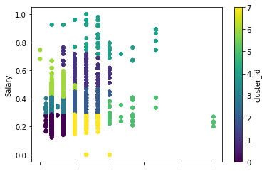

```python
jedf.plot.scatter(x='experience_years',
                  y='Salary',
                 c='cluster_id',
                 colormap='viridis')
```

```python
cstore = []
print(f"-- Total {len(kmeans.cluster_centers_)} clusters:")
for i, c in enumerate(kmeans.cluster_centers_):
    mask = jedf['cluster_id']==i
    minex = _jedf.loc[mask, 'experience_years'].min()
    maxex = _jedf.loc[mask, 'experience_years'].max()
    mins = _jedf.loc[mask, 'Salary'].min()
    maxs = _jedf.loc[mask, 'Salary'].max()
    jobcat = jedf.loc[mask, 'JobCat'].unique()
    cstore.append({
        'clusterid': i,
        'minex': minex,
        'maxex': maxex,
        'mins': mins,
        'maxs': maxs,
        'jobcat': jobcat,
        'njobcat': len(jobcat)
    })
#     print(f"-- Cluster_id {i}| Experience: {minex}-{maxex} Years | Salary: {mins}-{maxs}")
cdf = pd.DataFrame(cstore)
```

```
-- Total 8 clusters:
```

```python
cdf.sort_values('maxs', ascending=False)
```

|  | clusterid | minex | maxex | mins | maxs | jobcat | njobcat |
| --- | --- | --- | --- | --- | --- | --- | --- |
| 4 | 4 | 1.0 | 10.0 | 156829.0 | 234402.0 | [Engineering, Architecture, Planning Finance, ... | 42 |
| 1 | 1 | 2.0 | 6.0 | 113113.0 | 178873.0 | [Technology, Data, Innovation, Administration,... | 50 |
| 6 | 6 | 0.0 | 3.0 | 96898.0 | 175000.0 | [Administration, Human Resources, Engineering,... | 58 |
| 2 | 2 | 3.0 | 6.0 | 69940.0 | 112000.0 | [Engineering, Architecture, Planning, Finance,... | 55 |
| 3 | 3 | 0.5 | 2.0 | 67980.0 | 96020.0 | [Engineering, Architecture, Planning, Informat... | 79 |
| 5 | 5 | 6.0 | 15.0 | 46993.0 | 95270.0 | [Engineering, Architecture, Planning, Building... | 22 |
| 7 | 7 | 3.0 | 6.0 | 0.0 | 70900.0 | [Maintenance, Operations, Finance, Accounting,... | 61 |
| 0 | 0 | 0.5 | 2.0 | 28366.0 | 69595.0 | [Finance, Accounting, Procurement, Health Publ... | 88 |

### Now plotting a heat map of job categories with thier occurance in these clusters

```python
job_cat_index_hash = {x: i for i, x in enumerate(jedf.JobCat.unique())}
job_cat_index_hash
```

```
{'Maintenance': 0,
 'Operations': 1,
 'Finance': 2,
 'Accounting': 3,
 'Procurement': 4,
 'Health Public Safety': 5,
 'Inspections': 6,
 'Enforcement': 7,
 'Engineering': 8,
 'Architecture': 9,
 'Planning': 10,
 'Clerical': 11,
 'Administrative Support': 12,
 'Information Technology': 13,
 'Telecommunications': 14,
 'Procurement Information Technology': 15,
 'Community': 16,
 'Business Services': 17,
 'Administrative Support Legal': 18,
 'Administrative Support Community': 19,
 'Social Services': 20,
 'Health': 21,
 'Administrative Support Policy': 22,
 'Analysis': 23,
 'Business Services Social Services': 24,
 'Policy': 25,
 'Analysis Social Services': 26,
 'Telecommunications Policy': 27,
 'Legal Policy': 28,
 'Public Safety': 29,
 'Procurement Policy': 30,
 'Administration': 31,
 'Human Resources Legal Affairs': 32,
 'Research': 33,
 'Technology': 34,
 'Data': 35,
 'Innovation': 36,
 'Planning Building Operations': 37,
 'Building Operations': 38,
 'Human Resources': 39,
```

[output cut: 45 more lines]

```
 'Innovation Legal Affairs Building Operations': 85,
 'Maintenance Policy': 86,
 'Community Programs Health Social Services': 87,
 'Community Programs Public Safety': 88,
 'Innovation Public Safety': 89,
 'Intergovernmental Affairs Building Operations': 90,
 'Community Programs Building Operations': 91,
 'Intergovernmental Affairs Technology': 92,
 'Innovation Legal Affairs Policy': 93,
 'Community Programs Engineering': 94,
 'Human Resources Engineering': 95,
 'Procurement Social Services': 96,
 'Intergovernmental Affairs Legal Affairs': 97,
 'Intergovernmental Affairs Health Public Safety': 98,
 'Intergovernmental Affairs Finance': 99}
```

```python
heatmap_pixels = np.zeros((len(job_cat_index_hash), len(kmeans.cluster_centers_)), dtype=np.int32)
heatmap_pixels.shape
```

```
(100, 8)
```

```python
for _, row in jedf.reset_index().groupby(['JobCat', 'cluster_id']).count().iterrows():
    heatmap_pixels[job_cat_index_hash[row.name[0]]][row.name[1]] = row['index']
```

```python
heatmap_pixels
```

```
array([[ 93,   4,  23,  11,  13,  15,   2,  33],
       [  4,   0,   0,   0,   0,   0,   0,   4],
       [105,  28,  27,  56,   4,  10,  10,  40],
       [126,  32,  35,  77,  26,  12,  16,  54],
       [ 99,  28,  27,  56,   8,  10,  10,  40],
       [ 11,   0,   4,   9,   0,   0,   2,  16],
       [190,  30,  89, 121,  33,  30,  55, 200],
       [184,  30,  89, 119,  29,  30,  55, 196],
       [238,  69,  94, 324,  52,  45, 160, 104],
       [243,  75,  94, 335,  56,  45, 170, 104],
       [180,  43,  72, 238,  32,  40, 112,  59],
       [ 23,   0,   1,   1,   0,   0,   0,   7],
       [ 14,   0,   0,   0,   0,   0,   0,   6],
       [  8,   1,   1,  32,   0,   0,  14,   4],
       [ 10,   1,   1,  28,   0,   0,  14,   4],
       [  2,   0,   0,   0,   0,   0,   0,   0],
       [  6,   0,   1,   4,   0,   0,   0,   3],
       [  2,   0,   2,   0,   0,   0,   0,   4],
       [  8,   0,   0,   0,   0,   0,   0,   0],
       [  0,   0,   1,   0,   0,   0,   0,   1],
       [ 48,   2,  11,  42,   0,   0,   4,  23],
       [ 52,   2,  16,  26,   2,   0,   4,  36],
       [  1,   0,   0,   1,   0,   0,   0,   0],
       [209,  29,  29, 158,  12,   0,  41,  64],
       [  4,   0,   0,   4,   0,   0,   0,   0],
       [104,   8,  15,  72,   8,   0,  14,  59],
       [ 11,   1,   0,  12,   0,   0,   6,   0],
       [  0,   0,   0,   4,   0,   0,   0,   0],
       [  2,   0,   0,   2,   0,   0,   0,   0],
       [ 99,  12,  40,  20,   8,  28,  11, 118],
       [ 14,   4,   8,   8,   0,   0,   4,   6],
       [149,  32,  47,  73,  14,   2,  32, 105],
       [  4,   0,   4,   4,   0,   0,   2,   6],
       [231,  32,  40, 177,  21,   2,  49,  86],
       [102, 109, 166, 136,  16,   0, 116,  99],
       [126, 133, 176, 154,  22,   6, 128, 111],
       [ 88, 119, 172, 140,  16,   4, 114,  99],
       [  1,   2,   1,   0,   1,   1,   1,   3],
       [ 89,   2,  18,  10,   8,  14,   1,  16],
       [ 72,  10,  28,  17,   2,   0,  10,  73],
```

[output cut: 45 more lines]

```
       [  0,   0,   0,   0,   4,   0,   0,   0],
       [  2,   4,   0,   2,   6,   2,   0,   0],
       [  2,   0,   0,   0,   0,   0,   2,   0],
       [  9,   0,   0,   3,   0,   0,   0,   0],
       [  4,   2,   0,   0,   0,   0,   0,   2],
       [  2,   0,   0,   2,   0,   0,   0,   0],
       [  0,   0,   6,   0,   0,   0,   0,  12],
       [  4,   0,   0,   2,   0,   0,   2,   0],
       [  0,   0,   0,   2,   0,   0,   2,   0],
       [  2,   0,   0,   2,   0,   0,   4,   0],
       [  1,   4,   0,   2,   0,   0,   3,   0],
       [  2,   0,   0,   2,   0,   0,   0,   0],
       [  0,   2,   0,   0,   0,   0,   0,   2],
       [  0,   0,   2,   0,   0,   0,   0,   2],
       [  1,   0,   0,   1,   0,   0,   0,   0]], dtype=int32)
```

### linear Scale Plot

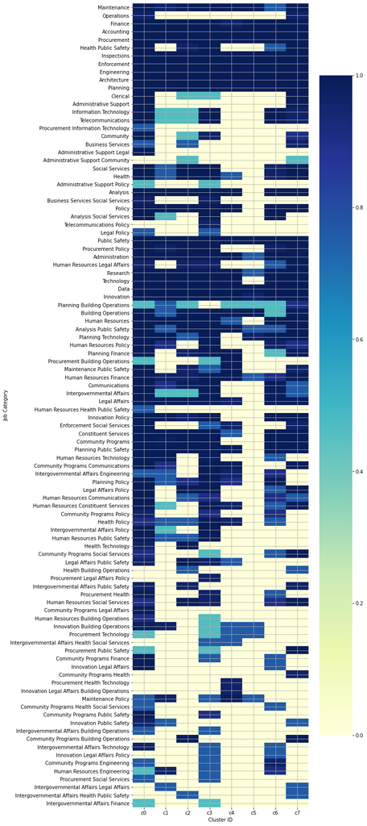

```python
f, ax = plt.subplots(figsize=(8, 30))
## Converting the heatmap to sigmoic values to convert the range to 0 to 1
_heatmap_pixels = ((1 / (1 + (np.exp(-heatmap_pixels))))-.5)*2
sns.heatmap(
    _heatmap_pixels,
    xticklabels=[f"c{i}"for i in list(range(len(kmeans.cluster_centers_)))],
    yticklabels=job_cat_index_hash.keys(),
    cmap="YlGnBu",
    ax=ax
)
plt.grid(True)
plt.xlabel('Cluster ID')
plt.ylabel('Job Category')
plt.show()
```

### Binary Scale Plot

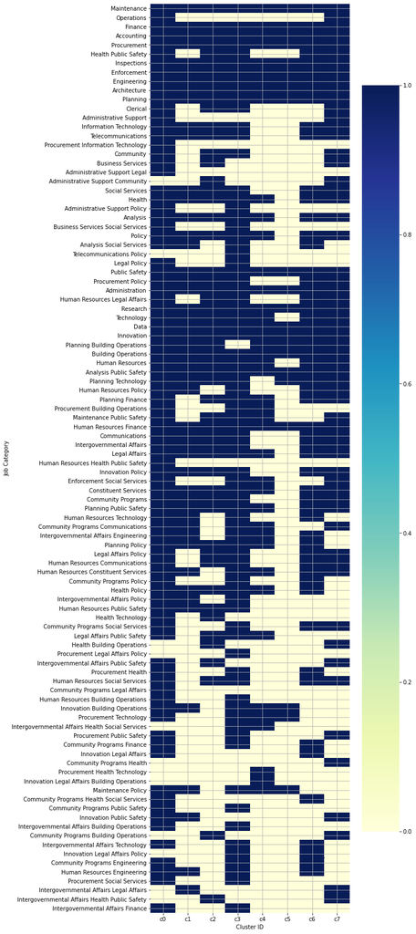

```python
f, ax = plt.subplots(figsize=(8, 30))
## Converting the heatmap to sigmoic values to convert the range to 0 to 1
_heatmap_pixels = heatmap_pixels > 0
sns.heatmap(
    _heatmap_pixels,
    xticklabels=[f"c{i}"for i in list(range(len(kmeans.cluster_centers_)))],
    yticklabels=job_cat_index_hash.keys(),
    cmap="YlGnBu",
    ax=ax
)
plt.grid(True)
plt.xlabel('Cluster ID')
plt.ylabel('Job Category')
plt.show()
```